# Homework: Conditional Statements and Flow Control

1. Find a minimize of the function $f(x)=(x-3)^4+7(x-2)^2+x$

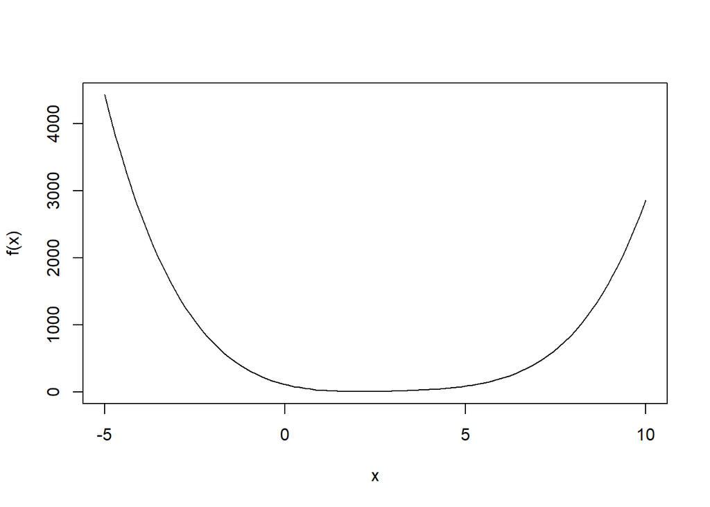

```r
f <- function(x) (x-3)^4+7*(x-2)^2+x
curve(f, from = -5, to = 10 )
```

2. Calculate factorial of a number using `while()` loop.

```r
n <- 5
factorial <- 1
i <- 1
while (i <= n) {
    factorial <- factorial * i
    i <- i + 1
}
print(factorial)
```

```
## [1] 120
```

3. Use `while()` loop to calculate the probability $P(X \leq 15)$ where $X$ is a Poisson random variable with mean $\lambda=20$.

```r
lambda <- 20
x <- 15
k <- 0
p0 <- exp(-lambda)
mySum <- p0
while (k < x){
  k <- k+1
  pi <- p0*lambda/k
  mySum <- mySum + pi
  p0 <- pi
}
mySum
```

```
## [1] 0.1565131
```

4. Use a `while()` loop to iteratively calculate the interest rate $i$ which satisfies the fixed-point equation
   $$i=(1-(1+i)^{-20})/19.$$
   Use a starting guess of $i=0.006$. Stop the calculation when two successive values of the interest rate are less than 0.000001 apart.

```r
m <- 20
i.old <- 0.006 # initial guess
SuccValue <- 0.1
while (SuccValue >0.000001 ) {
  i.new <- ( 1-(1+i.old)^{-m} )/ 19
  SuccValue <- abs(i.old-i.new)
  i.old <- i.new
}
i.old
```

```
## [1] 0.004954139
```

```r
( 1-(1+i.old)^{-m} )/ 19
```

```
## [1] 0.004953194
```

5. Let $f_n$ denote the $n$th Fibonacci number.  
   (a). Construct a sequence of ratios of the form $f_n/f_{n-1}$, $n=1,...,30$. Does the sequence appear to be converging?  
   (b). Compute the golden ratio $(1+\sqrt{5})/2$. Is the sequence converging to the ratio?

```r
N <- 30
Fibonacci <- numeric(N)
Fibonacci[1] <- 1
Fibonacci[2] <- 1
for (n in 3:N) Fibonacci[n] <- Fibonacci[n-1] + Fibonacci[n-2]
Fibonacci
```

```
##  [1]      1      1      2      3      5      8     13     21     34     55
## [11]     89    144    233    377    610    987   1597   2584   4181   6765
## [21]  10946  17711  28657  46368  75025 121393 196418 317811 514229 832040
```

```r
ratio <- c()
ratio[1] <- 1
for (n in 2:N) ratio[n] <- Fibonacci[n] / Fibonacci[n-1]
ratio
```

```
##  [1] 1.000000 1.000000 2.000000 1.500000 1.666667 1.600000 1.625000 1.615385
##  [9] 1.619048 1.617647 1.618182 1.617978 1.618056 1.618026 1.618037 1.618033
## [17] 1.618034 1.618034 1.618034 1.618034 1.618034 1.618034 1.618034 1.618034
## [25] 1.618034 1.618034 1.618034 1.618034 1.618034 1.618034
```

```r
(1+sqrt(5))/2
```

```
## [1] 1.618034
```

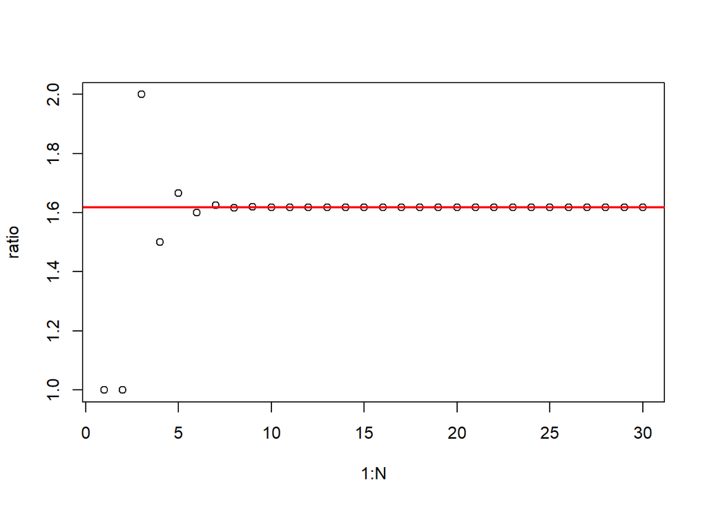

```r
plot(1:N, ratio)
abline(h = (1+sqrt(5))/2, lwd=2, col="red", xlab="n", ylab="Ratio")
```

6. Use a fixed-point iteration to determine the solution (in [0,1] ) of the equation $x=cos(x)$. Use a initial value of 0.5. How many iteration does it take before you have an answer which is accurate in the first two digits?

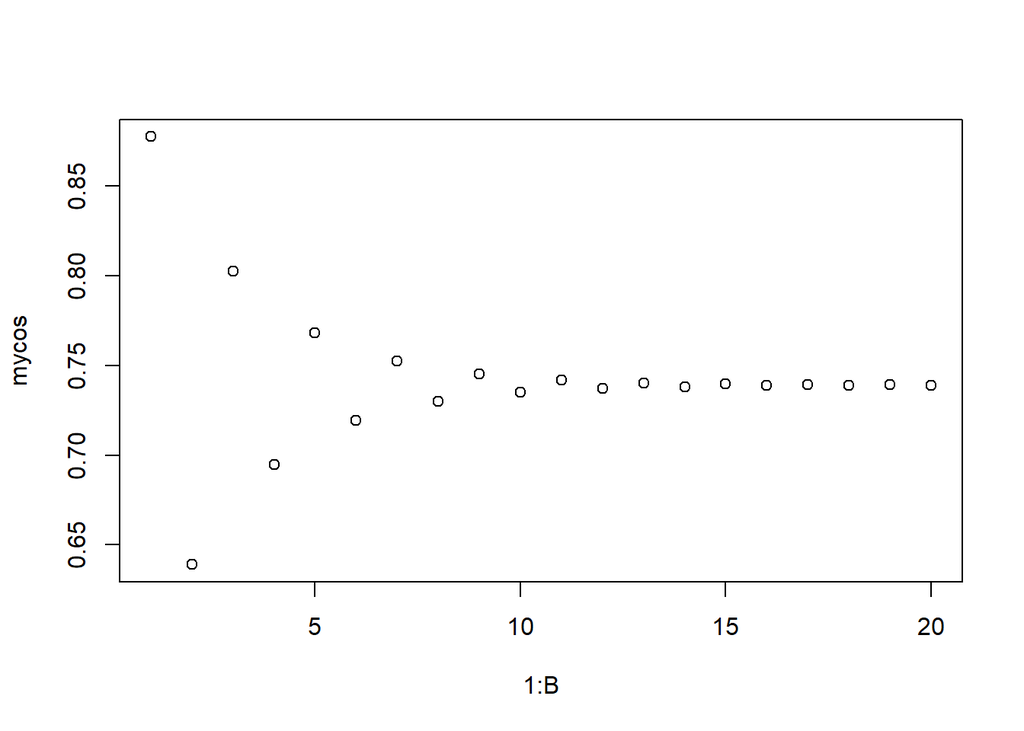

```r
B <- 20
x0 <- 0.5 # initial guess
mycos <- numeric(B)
mycos[1] <- cos(x0)
for (j in 2:B) {
  mycos[j] <- cos(mycos[j-1])
}
plot(1:B, mycos)
```

```r
cos(0.739)
```

```
## [1] 0.7391425
```

7. Based on the logic depicted in the figure below, write a R code to assign grades using `ifelse`.

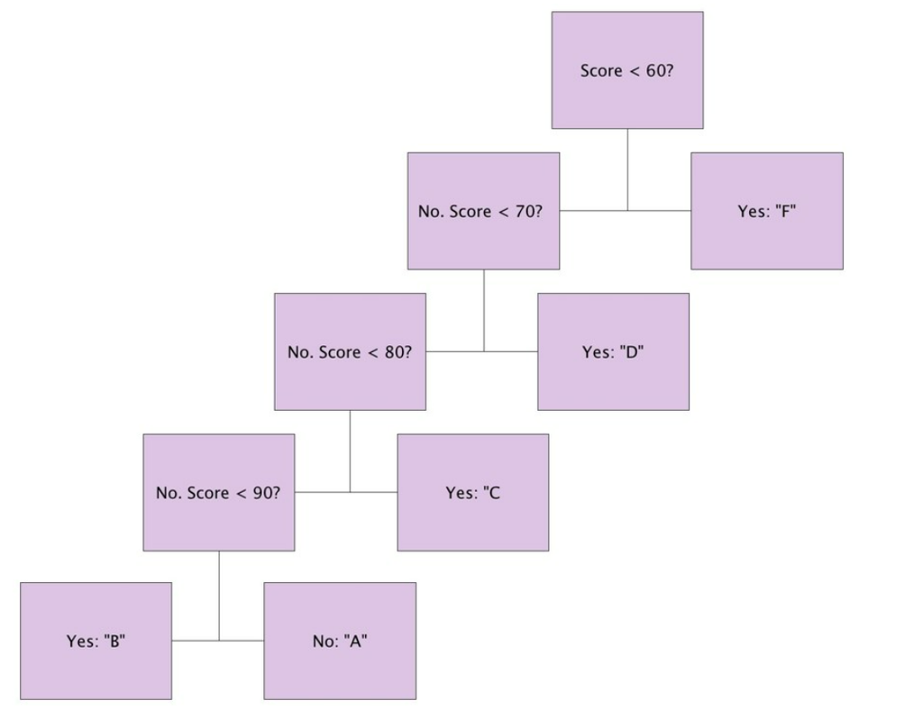

```r
final_score <- 55
grade<-ifelse(final_score<60,"F", ifelse (final_score<70,"D", ifelse(final_score<80,"C", ifelse (final_score<90,"B", "A"))))
grade
```

```
## [1] "F"
```